# Project Milestone Report - Predicting Monthly Income Range of Airbnb listing in NSW

Shannon Dussoye

26 February 2017

## Introduction

*Airbnb is an online marketplace and hospitality service, enabling people to list or rent short-term lodging including vacation rentals, apartment rentals, homestays, hostel beds, or hotel rooms.*

Airbnb has gained a lot of momentum over the past two years and is the most popular vacation rental stay due to its affordability. Many people have started listing their places to be rented on airbnb’s website. However, there is no tool available to new owners in order to get some insights on what will their monthly income. This model uses the scraped airbnb data - listings which contains all listings information; calendar - advanced bookings and all Points of Interests in NSW to calculate an average monthly income.

## Datasets

This project will use multiple datasets and create calculated metrics for each listing. The following dataset are using in this project:

1. listings
2. Calendars:
   - calendar_May2015
   - calendar_oct2015
   - calendar_dec2015
   - calendar_jan2016
   - calendar_dec2016
3. Points of Interests

### Listings dataset

The Listings contains all the information of a place being rented i.e. price, location, host details and etc. There are 95 attributes in the dataset. However, only 30% of the attributes will be used for this project. The dataset is displayed in the table below:

```
## [1] "table table-condensed table-bordered"
```

| id | listing_url | scrape_id | last_scraped | name | summary | space | description | experiences_offered | neighborhood_overview | notes | transit | access | interaction | house_rules | thumbnail_url | medium_url | picture_url | xl_picture_url | host_id | host_url | host_name | host_since | host_location | host_about | host_response_time | host_response_rate | host_acceptance_rate | host_is_superhost | host_thumbnail_url | … |
| --- | --- | --- | --- | --- | --- | --- | --- | --- | --- | --- | --- | --- | --- | --- | --- | --- | --- | --- | --- | --- | --- | --- | --- | --- | --- | --- | --- | --- | --- | --- |
| 13442565 | https://www.airbnb.com/rooms/13442565 | 20161204162736 | 2016-12-04 | Affordable single room | -parking available -bbq equipment -5min walk to train station -lidcombe to central only 19min by express train -nice people live here -quiet and safe | Big space,comfy | -parking available -bbq equipment -5min walk to train station -lidcombe to central only 19min by express train -nice people live here -quiet and safe Big space,comfy Kitchen Livingroom Bathroom I will… | none |  |  | Yes train is very convenient straight to opera house | Kitchen Livingroom Bathroom | I will find time even it is only a bit to have a chitchat with the guest |  | https://a2.muscache.com/im/pictures/67cc727b-f39e-4ba8-ae4d-c8b0514415b7.jpg?aki_policy=small | https://a2.muscache.com/im/pictures/67cc727b-f39e-4ba8-ae4d-c8b0514415b7.jpg?aki_policy=medium | https://a2.muscache.com/im/pictures/67cc727b-f39e-4ba8-ae4d-c8b0514415b7.jpg?aki_policy=large | https://a2.muscache.com/im/pictures/67cc727b-f39e-4ba8-ae4d-c8b0514415b7.jpg?aki_policy=x_large | 51124989 | https://www.airbnb.com/users/show/51124989 | Yuni | 2015-12-12 | Sydney, New South Wales, Australia |  | within a few hours | 100% | N/A | f | https://a2.muscache.com/im/pictures/53c7c9c7-a020-472d-bc9a-e4a06d498606.jpg?aki_policy=profile_small | … |
| 13442098 | https://www.airbnb.com/rooms/13442098 | 20161204162736 | 2016-12-04 | Sydney Olympic Park High Level Stunning View Apt | This brand new two-bedroom apartment with 2 bathroom at high level of the iconic Australia Tower in the heart of Sydney Olympic Park. Our place is welcoming. It contains 2 urban design bedrooms with b… |  | This brand new two-bedroom apartment with 2 bathroom at high level of the iconic Australia Tower in the heart of Sydney Olympic Park. Our place is welcoming. It contains 2 urban design bedrooms with b… | none | Guests will enjoy an abundance of world class sporting and recreation facilities on their doorstep, as well as being surrounded by Australia's largest urban Parkland. Sydney Olympic Park provides a un… |  | Restaurants, Convenience store,shopping bus and train station at door step. Ikea, DFO and shopping centres within minutes' drive Easy and short access to M4&amp;A3 | Stylish furniture include lounge, dining table, beds, full equipped kitchen, television and much more! High Speed NBN Internet secure parking spot in the building Video Security Intercom Fully equippe… | We are always contactable by mobile, SMS, E-mail or airbnb. Please feel free to get in touch with me, If you have any questions about where to eat, where to shopping etc. | - - No parties, events or group gatherings. - -Check-in time is 3.30pm or earlier on request, if available - -Check-out time is 12pm, however we have a generous late checkout - - Policy which is subje… | https://a2.muscache.com/im/pictures/a9d2c1e7-36f0-4c01-8730-dcf8d3291868.jpg?aki_policy=small | https://a2.muscache.com/im/pictures/a9d2c1e7-36f0-4c01-8730-dcf8d3291868.jpg?aki_policy=medium | https://a2.muscache.com/im/pictures/a9d2c1e7-36f0-4c01-8730-dcf8d3291868.jpg?aki_policy=large | https://a2.muscache.com/im/pictures/a9d2c1e7-36f0-4c01-8730-dcf8d3291868.jpg?aki_policy=x_large | 76721545 | https://www.airbnb.com/users/show/76721545 | Nicole | 2016-06-09 | Australia |  | within an hour | 100% | N/A | t | https://a2.muscache.com/im/pictures/3bd8c649-5f84-4662-99f1-86c76ea9e2eb.jpg?aki_policy=profile_small | … |
| 10574226 | https://www.airbnb.com/rooms/10574226 | 20161204162736 | 2016-12-04 | Spacious ground floor appartment | Cool, relax home with private side access. 18kms from Sydney CBD, only walking distance to Sydney Olympic Park. | 1 bedroom with matress on floor with 1 bathroom/toilet. Free Internet, onsite street parking available and can organise undercover parking @20per night. Opposite to recreation center and river walks. | Cool, relax home with private side access. 18kms from Sydney CBD, only walking distance to Sydney Olympic Park. 1 bedroom with matress on floor with 1 bathroom/toilet. Free Internet, onsite street par… | none | Close to Sydney Olympic Park, DFO Homebush, Train station and bus stop (526 Route). Also 15 mins walk to Olympic ferry station, 2 mins walks to river walks | Recreation center opposite with gym, pools, tennis and the tennis. Additional cost and not covered with stay. Also 2 mins walk to access The Piazza and cafes, amenities and medical center. Presently y… | Bus route 526 to Burwood station, via DFO Homebush, Olympic station and Strathfield Station | Free Internet, use and clean kitchen appliances and utensils, washing machine and dryers, tv and others. | Interactions on weekdays before 7.30am ad after 6pm. Sms anytime. Weekly lifts to Strathfield station. | No pets and no smoking zone. Appreciate privacy and happy to interact. Strickly no download of movies or NY other illegal activites, storage or possession. | https://a2.muscache.com/im/pictures/0d08c43e-94b1-4f5d-9bb2-466ee153c568.jpg?aki_policy=small | https://a2.muscache.com/im/pictures/0d08c43e-94b1-4f5d-9bb2-466ee153c568.jpg?aki_policy=medium | https://a2.muscache.com/im/pictures/0d08c43e-94b1-4f5d-9bb2-466ee153c568.jpg?aki_policy=large | https://a2.muscache.com/im/pictures/0d08c43e-94b1-4f5d-9bb2-466ee153c568.jpg?aki_policy=x_large | 43986820 | https://www.airbnb.com/users/show/43986820 | Rohil | 2015-09-12 | Australia |  | N/A | N/A | N/A | f | https://a1.muscache.com/im/users/43986820/profile_pic/1442046151/original.jpg?aki_policy=profile_small | … |
| 10869120 | https://www.airbnb.com/rooms/10869120 | 20161204162736 | 2016-12-04 | Single room 7.7 square meters. | Near railway station 800 meters. |  | Near railway station 800 meters. Near Auburn Station | none |  | No cooking | Near Auburn Station |  |  | No cooking. | https://a2.muscache.com/im/pictures/98619de8-d4f3-41e4-8e32-3cd665c855df.jpg?aki_policy=small | https://a2.muscache.com/im/pictures/98619de8-d4f3-41e4-8e32-3cd665c855df.jpg?aki_policy=medium | https://a2.muscache.com/im/pictures/98619de8-d4f3-41e4-8e32-3cd665c855df.jpg?aki_policy=large | https://a2.muscache.com/im/pictures/98619de8-d4f3-41e4-8e32-3cd665c855df.jpg?aki_policy=x_large | 47437319 | https://www.airbnb.com/users/show/47437319 | Fang | 2015-10-26 | AU | Hello, my friend!This is Amanda and little DD in the picture. DD is a smart cat lives in backyard, you could call him for a warm rubber if you like cats . I worked in a league office before I came to … | within an hour | 100% | N/A | f | https://a2.muscache.com/im/pictures/6cde530c-a11f-4b4a-8fe8-83abb64e8bd1.jpg?aki_policy=profile_small | … |
| 1169841 | https://www.airbnb.com/rooms/1169841 | 20161204162736 | 2016-12-04 | Breakers Cove, waterfront view | Breakers Cove is a lovely 2 bedroom, 2 bathroom waterfront apartment with direct access to beach lagoon pool, heated pool, a fully equipped gym and sauna. Featuring stylish furnishings and combined li… | Breakers Cove is a lovely 2 bedroom, 2 bathroom waterfront apartment. Featuring a beach lagoon pool, heated pool, a fully equipped gym and sauna. This apartment has stylish furnishings featuring a com… | Breakers Cove is a lovely 2 bedroom, 2 bathroom waterfront apartment with direct access to beach lagoon pool, heated pool, a fully equipped gym and sauna. Featuring stylish furnishings and combined li… | none | Located approximately 20 minutes to Sydney CBD and Darling Harbor and only 10 minutes walk to Fast Cat ferry terminal. Breakers Cove is situated close to the M4 and between the Rivercat ferry terminal… | Bed Configuration: Master bedroom: 1 Queen bed size (no chance to split into 2 singles) 2nd bedroom: 1 Queen bed size (no chance to split into 2 singles) Single Roll away bed and Porta-cot available u… | Train Station: Olympic Park station is 2.3 km away Ferry Station: Olympic Park Ferry Wharf is 1.4 km away Venue: ANZ Stadium is 2.5 km away Venue: Allphones Arena is 2.2 km away Venue: Skoda Stadium i… | Access to the beach lagoon pool, heated pool, a fully equipped gym and sauna is allowed between 7am - 7pm. | We have a 24/7 Hotline in case you need information to make your stay even more enjoyable. Our Hotline is always available in case you need support for problems with applaiances or any other issue dur… | Number of Guests should not exceed the number stated on the Confirmation Notice or subsequently agreed in writing or email. Fees will apply for excess guests not agreed with the owners in advance. Par… | https://a2.muscache.com/im/pictures/17590229/8a1b6c99_original.jpg?aki_policy=small | https://a2.muscache.com/im/pictures/17590229/8a1b6c99_original.jpg?aki_policy=medium | https://a2.muscache.com/im/pictures/17590229/8a1b6c99_original.jpg?aki_policy=large | https://a2.muscache.com/im/pictures/17590229/8a1b6c99_original.jpg?aki_policy=x_large | 6050952 | https://www.airbnb.com/users/show/6050952 | Lisa &amp; Alessandro | 2013-04-23 | Mount Martha, Victoria, Australia | Lisa lives in Victoria and Alessandro (married with Lisa's niece) comes from Rome but is currently living in Ibiza (Spain). Lisa started in 2008 with a couple of properties she owns in Victoria and Qu… | within an hour | 92% | N/A | f | https://a2.muscache.com/im/users/6050952/profile_pic/1366691022/original.jpg?aki_policy=profile_small | … |
| 5641597 | https://www.airbnb.com/rooms/5641597 | 20161204162736 | 2016-12-04 | Australia Towers 14.07, New choice! | Australia Towers 14.07 is a new spacious 2 bedroom apartment with panoramic city and park views. A roll away single bed can be added upon request so the unit can comfortably accommodate 5 guests. | Our apartment is sophisticated, elegant and generously proportioned and designed to suit a variety of people and demographics. Corporate guests or families with children of all ages will also apprecia… | Australia Towers 14.07 is a new spacious 2 bedroom apartment with panoramic city and park views. A roll away single bed can be added upon request so the unit can comfortably accommodate 5 guests. Our … | none | Guests will enjoy an abundance of world class sporting and recreation facilities on their doorstep, as well as being surrounded by Australia's largest urban Parkland. Sydney Olympic Park provides a un… | Air Conditioning: Living and all bedrooms with split system Bed Configuration: Master bedroom: 1 Kingbed size (chance to split into 2 long singles)* 2nd bedroom: 2 long singles (or one King size bed)*… | Train Station: Olympic Park station is 400 meters away Ferry Station: Olympic Park Ferry Wharf is 3.3 km away Venue: ANZ Stadium is 1.2 km away Venue: Allphones Arena is 1.5 km away Venue: Skoda Stadi… | Australia Towers has no common facilities as a pool, gym or others | We have a 24/7 Hotline in case you need information to make your stay even more enjoyable. Our Hotline is always available in case you need support for problems with applaiances or any other issue dur… | Number of Guests should not exceed the number stated on the Confirmation Notice or subsequently agreed in writing or email. Fees will apply for excess guests not agreed with the owners in advance. Par… | https://a2.muscache.com/im/pictures/70212351/8e8c9d80_original.jpg?aki_policy=small | https://a2.muscache.com/im/pictures/70212351/8e8c9d80_original.jpg?aki_policy=medium | https://a2.muscache.com/im/pictures/70212351/8e8c9d80_original.jpg?aki_policy=large | https://a2.muscache.com/im/pictures/70212351/8e8c9d80_original.jpg?aki_policy=x_large | 6050952 | https://www.airbnb.com/users/show/6050952 | Lisa &amp; Alessandro | 2013-04-23 | Mount Martha, Victoria, Australia | Lisa lives in Victoria and Alessandro (married with Lisa's niece) comes from Rome but is currently living in Ibiza (Spain). Lisa started in 2008 with a couple of properties she owns in Victoria and Qu… | within an hour | 92% | N/A | f | https://a2.muscache.com/im/users/6050952/profile_pic/1366691022/original.jpg?aki_policy=profile_small | … |

After removing meaningless attributes, e.g. scrape_id, space and etc. The dataset set looks as depicted in the table below.

```
## [1] "table table-condensed table-bordered"
```

| id | listing_url | host_id | host_since | city | latitude | longitude | property_type | room_type | accommodates | bathrooms | bedrooms | beds | bed_type | price | security_deposit | cleaning_fee | guests_included | extra_people | minimum_nights | number_of_reviews | review_scores_rating | review_scores_accuracy | review_scores_cleanliness | review_scores_checkin | review_scores_communication | review_scores_location | review_scores_value | cancellation_policy |
| --- | --- | --- | --- | --- | --- | --- | --- | --- | --- | --- | --- | --- | --- | --- | --- | --- | --- | --- | --- | --- | --- | --- | --- | --- | --- | --- | --- | --- |
| 13442565 | https://www.airbnb.com/rooms/13442565 | 51124989 | 2015-12-12 | Lidcombe | -33.8607167414506 | 151.047836129256 | Townhouse | Private room | 2 | 1 | 1 | 1 | Real Bed | $40.00 |  |  | 1 | $0.00 | 1 | 0 |  |  |  |  |  |  |  | flexible |
| 13442098 | https://www.airbnb.com/rooms/13442098 | 76721545 | 2016-06-09 | Sydney Olympic Park | -33.8467339961345 | 151.073425982683 | Apartment | Entire home/apt | 6 | 2 | 2 | 2 | Real Bed | $225.00 | $300.00 | $65.00 | 4 | $30.00 | 1 | 29 | 98 | 10 | 10 | 10 | 10 | 10 | 10 | strict |
| 10574226 | https://www.airbnb.com/rooms/10574226 | 43986820 | 2015-09-12 | Wentworth Point | -33.8307038896523 | 151.073442055624 | Apartment | Private room | 2 | 1 | 1 | 1 | Real Bed | $90.00 | $200.00 |  | 0 | $0.00 | 1 | 1 | 100 | 10 | 10 | 10 | 10 | 10 | 10 | flexible |
| 10869120 | https://www.airbnb.com/rooms/10869120 | 47437319 | 2015-10-26 | Auburn | -33.8488875515161 | 151.027772343039 | House | Private room | 1 | 1 | 1 | 1 | Real Bed | $34.00 | $150.00 | $17.00 | 0 | $0.00 | 1 | 27 | 90 | 9 | 9 | 9 | 9 | 9 | 9 | strict |
| 1169841 | https://www.airbnb.com/rooms/1169841 | 6050952 | 2013-04-23 | Sydney Olympic Park | -33.8340760721572 | 151.074646022512 | Apartment | Entire home/apt | 5 | 2 | 2 | 2 | Real Bed | $321.00 | $500.00 | $120.00 | 4 | $50.00 | 3 | 6 | 97 | 10 | 10 | 10 | 9 | 9 | 9 | flexible |
| 5641597 | https://www.airbnb.com/rooms/5641597 | 6050952 | 2013-04-23 | Sydney Olympic Park | -33.8466735012754 | 151.073180646213 | Apartment | Entire home/apt | 5 | 2 | 2 | 4 | Real Bed | $335.00 | $500.00 | $120.00 | 4 | $50.00 | 2 | 11 | 96 | 10 | 10 | 10 | 10 | 10 | 10 | strict |

### Calendars dataset

The Calendars datasets are scraped at specific date and contains data for a specific range. The calendar dataset contains the dates on which a place is booked but does not contain historical data i.e. weather the place was rented two years ago. Therefore, all the dataset are merged together to calculate an average number of days that a place is rented. The mean and median number of days that a place is rented is calculated.

### Points of Interest Dataset

The Points of Interest dataset contains a filtered list of POI in NSW. There are around 150,000 POI in NSW and to keep the project simple, only the following POI categories were considered:

- Zoo
- City
- Lighthouse
- Observatory
- Transport Interchange
- Art Gallery
- Tourist Attraction
- Museum
- Waterfall
- Historic Site
- TownShopping Centre
- Railway Station
- Beach

## Important Information in Datasets

All the datasets that are used contains relevant attributes that will be used to create the model. For example, the listings dataset contains the price, geolocation and listing details; the calendar dataset contains the pre-booking information and helps to calculate the mean/median number of days a place was rented. The POI dataset contains geolocation, categories and name of the POIs.

## Limitations

One of the main limitations for this project is that historical bookings is not available. Historical booking information would have helped to calculate an accurate average number of days a place was rented. Furthermore, the calendar listings are not complete i.e. we do not have a full quarter or year of data to work with.

## Data Cleaning/Wrangling

The Airbnbs’ datasets used were already cleaned and therefore did not need any more cleansing. However, there is a lot of wrangling required in order to have meaningful attributes, for example:

- Merging all calendar dataset to summarise booking information
- Calculating the distance between all listings and POIs and filtering to use POI within 10 km radius of listings
- Filtering the dataset to use the closest city and trains stations if there are multiple

## Preliminary Explorations

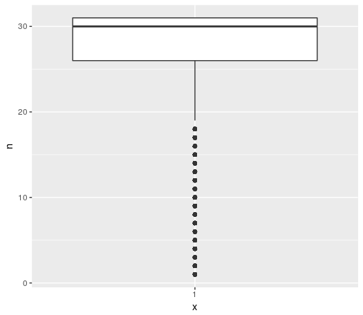

## Approach

Initially, the approach was to predict the probability that a place will be rented based on POI and calculated reviews score. However, we have slightly change the approach to predict an average income range per month for a listing and to use the existing airbnb reviews instead of scoring reviews from the reviews dataset. The mathematical approach to the problem is to an Ensemble Modelling technique consisting of Logistic Regression, Support Vector Machines and Decision Trees. A voting mechanism will be used to select the most accurate response.